# runModelExample

Zoey Werbin

4/10/2020

For my EE509 project, I created models to describe fluctuations in soil microbial relative abundances. Soil microbes control many of the Earth’s biogeochemical processes, and we currently have limited understanding of how the soil microbiome changes over time. I focus on taxa from two major groups - bacteria and fungi - which each play important roles in decomposition, nitrogen cycling, etc. In this Rmarkdown, we will fit my model to a single group, but for my full analysis (summarized in `PrelimResults.rmd`), I fit this model to 60 different groups.

First, we load libraries and a couple of custom scripts:

```r
library(rjags)
library(runjags)
library(dplyr)
library(arm) #for invlogit function
library(tidyr)
```

```r
library(ggplot2)
library(ecoforecastR)
source("../functions/helperFunctions.r")
source("../functions/prepModelData.r")

# Read in covariate data
cov <- readRDS("/projectnb/talbot-lab-data/zrwerbin/temporal_forecast/data/clean/EE509_model_covariates.rds")
weather <- cov[[1]]
plot_pH <- cov[[2]]

# Read in the microbial abundance data
d <- readRDS("/projectnb/talbot-lab-data/zrwerbin/temporal_forecast/data/clean/groupAbundances_EE509.rds")
```

Next, we subset to one particular group (Acidobacteria) and format the data for analysis. Microbial abundance (our response variable) is measured for a soil core, and there are a few soil cores that are replicates for a given plot. About 5-10 plots are in a site, and there are five sites across the country. The dataset therefore has 1095 soil cores, 67 plots, and 5 sites.

```r
rank.df <- d[[1]] # Subsetting bacterial phyla
rank.df$dates <- gsub("2016", "2015", rank.df$dates) # Replacing 2015 with 2016 to avoid a huge gap in dataset.
model.dat <- prepModelData(weather, plot_pH, rank.df, j=1) # Combine using custom function
dat <- model.dat[[1]]
y <- model.dat[[2]]
temp.cov <- model.dat[[3]]
precip.cov <- model.dat[[4]]
pH.cov <- model.dat[[5]]

plot_site <- model.dat[[6]]
plot.truth <- model.dat[[7]]
site.truth <- model.dat[[8]]

# Create data object.
data <- list(y = as.matrix(y),
             N.core = length(dat$y),
             N.plot = length(unique(dat$plotID)),
             N.site = length(unique(dat$siteID)),
             N.date = length(unique(dat$dateID)),
             plot_site = droplevels(as.factor(plot_site)),
             plotID = droplevels(as.factor(dat$plotID)),
             temp = temp.cov,
             precip = precip.cov,
             pH = pH.cov
)
```

Let’s take a look at the data we’re using. We have temperature and precipitation data for each site and each month, and pH values for each plot. Covariates have been mean-centered. Y values range from 0 to 1 (closed interval).

```r
temp.cov[,1:5]
```

```
##          201306    201307     201308    201309    201310
## [1,] -1.6482634 -1.409576 -1.2228406 -2.823955 -6.736992
## [2,]  3.3614087  2.155383  3.3657599  5.140117  9.673794
## [3,] -4.9585119 -2.084871 -4.8607481 -5.836670 -4.343909
## [4,]  3.5532054  2.169019  3.2114055  4.995748  8.068531
## [5,] -0.3078387 -0.829956 -0.4935767 -1.475239 -6.661424
```

```r
precip.cov[,1:5]
```

```
##          201306     201307     201308     201309     201310
## [1,] -1.2785168 -0.7865242 -0.6962886  0.3346680  0.3747697
## [2,]  0.9252362  1.0064418  0.4930717  0.3847813 -0.3051001
## [3,]  0.6938084 -0.1696102  0.2448635 -0.6802866 -0.0186595
## [4,]  0.7539446  0.7413473  0.6235959  0.1309060 -0.1067578
## [5,] -1.0944724 -0.7916547 -0.6652425 -0.1700687  0.0557478
```

```r
head(pH.cov)
```

```
## CPER_001 CPER_002 CPER_003 CPER_004 CPER_005 CPER_006
## 2.040467 1.072501 2.163908 2.075075 1.694344 1.003831
```

```r
head(dat); dim(dat)
```

```
##    siteID   plotID dateID                    coreID         y
## 49   STER STER_003 201306  STER_003-M-38-5-20130627 0.2223811
## 50   STER STER_003 201306 STER_003-M-22-37-20130627 0.2065249
## 51   STER STER_004 201306  STER_004-M-1-21-20130627 0.2305928
## 52   STER STER_004 201306  STER_004-M-3-10-20130627 0.2096682
## 53   STER STER_004 201306 STER_004-M-22-33-20130627 0.2034131
## 54   STER STER_005 201306  STER_005-M-5-35-20130627 0.1486465
```

```
## [1] 1095    5
```

Now, let’s look at and fit our model. The JAGS code has a data model at the core level, because each core is a replicate for one plot. This data is drawn from the beta distribution, with a logit link function to prevent any values outside of 0 or 1. The process model, with the environmental covariates, is at the plot level. We have random effects for each site, each plot, and each time point.

```r
model_string <- " model{

#### Core-level observations ####
for (t in 1:N.date){
  for (i in 1:N.core){
    y[i,t] ~ dbeta(alpha[i,t], beta[i,t]) ## Data model: core observations are a function of alpha and beta
    alpha[i,t] <- plot_mean[plotID[i],t] * tau
    beta[i,t]  <- (1-plot_mean[plotID[i],t]) * tau
  }
}

#### Plot means - Process model ####
for (i in 1:N.plot){
  for (t in 2:N.date){
    logit(plot_mean[i,t]) <-  beta_IC*plot_mean[i,t-1] + beta_precip*precip[plot_site[i],t] + beta_temp*temp[plot_site[i],t] + beta_pH*pH[i] + site_effect[plot_site[i]] + plot_effect[i] + time_effect[t]
  }
}

#### Priors ####

for (i in 1:N.site){
  site_effect[i] ~ dnorm(0,site_var)  # Prior on site random effects
}

for (i in 1:N.plot){
  plot_mean[i,1] ~ dbeta(1,3)  # Prior on plot means for first date
  plot_effect[i] ~ dnorm(0, plot_var) # Prior on plot random effects
}

for (t in 1:N.date){
  time_effect[t] ~ dnorm(0, time_var) # Prior on time random effects
}

# Coefficient priors
beta_IC ~ dnorm(0,0.2)
beta_temp ~ dnorm(0,.2)
beta_pH ~ dnorm(0,.2)
beta_precip ~ dnorm(0,.2)

# Variance priors
tau ~ dgamma(1,.1)
plot_var ~ dgamma(1,.1)
site_var ~ dgamma(1,.1)
time_var ~ dgamma(1,.1)
}"

monitor <- c("beta_IC","beta_temp","beta_precip","beta_pH","tau",
             "plot_var","plot_mean","site_effect","plot_effect","time_effect")

pmod <- run.jags(model_string,
                 data = data,
                 adapt = 500,
                 burnin = 500,
                 sample = 500,
                 n.chains = 3,
                 thin = 5,
                 method = "rjparallel",
                 jags = "/share/pkg.7/jags/4.3.0/install/bin/jags",
                 monitor = monitor)
```

```
## Compiling rjags model...
## Starting 3 rjags simulations using a Fork cluster with 3 nodes on
## host 'localhost'
## Simulation complete
## Note: Summary statistics were not produced as there are >50
## monitored variables
## [To override this behaviour see ?add.summary and ?runjags.options]
## FALSEFinished running the simulation
```

```r
# # Pull out plot values
plot_mean <- summary(pmod, vars="plot_mean")
```

```
## Calculating summary statistics...
## Calculating the Gelman-Rubin statistic for 1675 variables....
## Note: Unable to calculate the multivariate psrf
```

```r
plot_out <- data.frame(plot_int_mean = plot_mean[,4],
                       plot_int_lo95 = plot_mean[,1],
                       plot_int_hi95 = plot_mean[,3])
plot_out$truth <- plot.truth$plot_mean
plot_out$plotID <- plot.truth$plotID
plot_out$dateCol <- as.Date(paste0(as.character(plot.truth$dateID), '01'), format='%Y%m%d')
plot_out$siteID <- plot.truth$siteID
plot_out$psrf <- plot_mean[,11]
plot_out$SSeff <- plot_mean[,9]
```

Let’s view our model fit for a single plot:

```r
  mfit <- pmod$mcmc[[1]]
  # Create confidence interval for the calibration period.
  plotpreds <- mfit[,grep(paste0("plot_mean[1,"), colnames(mfit),fixed=TRUE)]
  plot.cal.ci <- apply(plotpreds,2,quantile,c(0.025,0.5,0.975))
  # Pull out predictive variance and convert to standard deviation
  tau <- summary(pmod, vars="tau")[4]
```

```
## Calculating summary statistics...
## Calculating the Gelman-Rubin statistic for 1 variables....
```

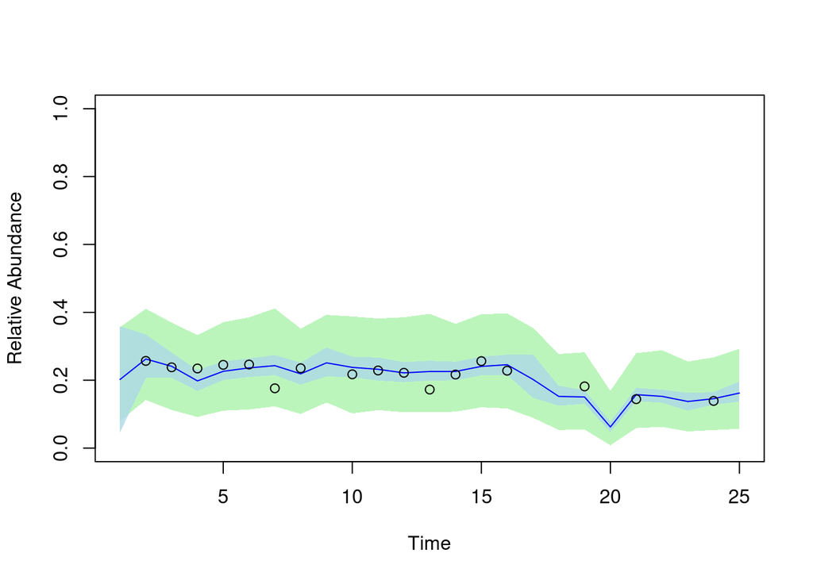

```r
  # Create predictive interval
  plot.cal <- sapply(plot.cal.ci[2,], function (x) rbeta(500, mean(tau) * x, mean(tau) * (1 - x)))
  plot.cal.pi <- apply(plot.cal,2,quantile,c(0.025,0.5,0.975))
  # Create and view plot!
  plot(1:25,1:25,type='n', ylim=c(0,1), ylab="Relative Abundance", xlab = "Time")
  ecoforecastR::ciEnvelope(1:25,plot.cal.pi[1,],plot.cal.pi[3,],col=col.alpha("lightGreen",0.6))
  ecoforecastR::ciEnvelope(1:25,plot.cal.ci[1,],plot.cal.ci[3,],col=col.alpha("lightBlue",0.8))
  lines(1:25,plot.cal.ci[2,],col="blue")
  obs <- plot_out[grep(paste0("plot_mean[1,"), rownames(plot_out),fixed=T),]$truth
  points(obs)
```